# Replication of You call it ‘Self-Exhuberance’; I call it ‘Bragging’: Miscalibrated Prediction of Emotional Responses to Self-Promotion (Study 2) by Scopelliti, Loewenstein, Vosgerau (2015, *Psychological Science*)

Replicated by Jaclyn Schwartz; contact: jschwar2@stanford.edu

November 27, 2017

## Introduction

Scopelliti et al., 2015 explored how self-promotion (i.e., communicating one’s positive traits) can lead to contradicting emotional perspectives. The self-promoter may perceive that the recipient feels more positive emotions and less negative emotions about the promoter’s behavior than the recipient’s true emotional reaction. These “failures of emotional perspective taking” can have negative consequences, where recipients may see the self-promoters as bragging. The authors argued that “people tend to underestimate differences between their own and others’ emotional reactions” by using their own emotions as “anchors to estimate” their recipient’s emotions. They hypothesized that “self-promoters will overestimate the extent to which their behavior elicits positive emotional reactions in others, and underestimate the extent to which their behavior elicits negative emotional reactions.”

## Methods

### Power Analysis

I used G*Power 3.1 to conduct my a priori power analysis to plan the sample size. Specifically, I used a repeated-measures ANOVA for the main within-between (emotion x condition) interaction to plan my sample size since the authors used a 2-way mixed ANOVA, with 2 (between) groups and 7 (within) measurements to calculate their effects. The authors’ reported effect size was $\eta_{p}^{2}$ = .07, which corresponds to effect size of f = 0.274. I set $\alpha$ = .05. In order to achieve 80% power, the yielded sample size was very small (N=16) either because the authors over-powered their sample number or the analysis yielded a huge effect. Therefore, I set the power to = .95 to increase the proposed sample size. Thus, my determined sample size is 50 to achieve 95% power.

[figure not shown]

G*power screenshot to determine sample size

### Planned Sample

We are planning to recruit 50 (25 per condition) workers based on the power analysis. The authors “restricted participation to respondents who were located in the United States and had not participated in Experiment 1.” We will therefore restrict participation to those located in the United States. Experiment 2 is the only study from the paper undergoing replication at this time, so the “previous participation” preselection rule does not apply.

### Materials

All materials were accessed through OSF (https://osf.io/evikb/). Participants completed *one* of the two surveys depending on random condition assignment. One survey (self-promotion) asks, “Can you describe a situation in which you have bragged to someone else about something? Please be as detailed as possible.” There is then a series of 7 “discrete emotions” (pride, happiness, annoyance, feeling inferior, jealousy, upset, anger), in which participants are asked, “how you think the person you bragged to has felt in that situation” on a scale from 1 – 7 (*1=not at all to 7=very much*). The other survey (recipient-of-self-promotion) asks, “Can you describe a situation in which someone has bragged to you about something? Please be as detailed as possible.” There is then a series of the same 7 “discrete emotions” , in which participants are asked to rate “how you felt in the situation you just described” on a scale from 1 – 7 (*1=not at all to 7=very much*).

### Procedure

Participants completed a short survey on Amazon Mechanical Turk (MTurk). Participants were randomly assigned to one of two conditions: the self-promotion condition or the recipient-of-self-promotion condition. “Sample size was set to a minimum of 75 participants per condition, and the data were analyzed only after data collection had been completed. 154 Amazon Mechanical Turk workers accessed and completed a short study on personality and received $0.50 as compensation. As in Experiment 1, participants described an instance of having engaged in self-promotion or having been the recipient of someone else’s self-promotion. Next, participants in the self-promotion condition were asked to indicate the extent to which their counterpart had felt happy for, proud of, annoyed by, jealous of, angry at, upset by, and inferior to them, whereas participants in the recipient-of-self-promotion condition were asked to rate their own level of these experienced feelings.” The between-subjects factor is “reporter” (either self-promoter **or** recipient). The emotions are considered a within-subjects factor only because participants in both conditions rate the same emotions. See Table 5 from paper. “All emotions were rated on 7-point scales from *not at all* (1) to *very much* (7).” The replication will instead recruit 25 participants per condition based on the power analysis, and pilot data has been collected and analyzed. My pilot data suggest that the survey takes approximately 4-5 minutes to complete, so participants will receive 60 cents as compensation.

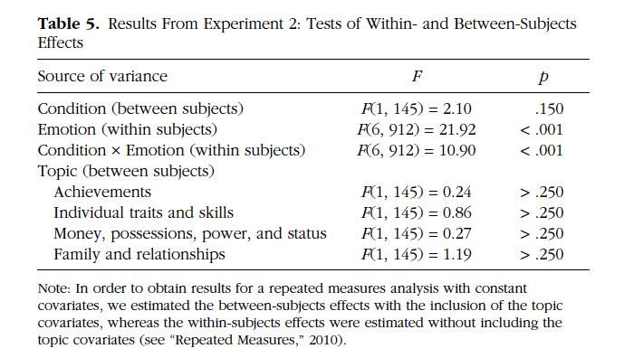

Table 5. Results of Experiment 2 showing the factors of this mixed-design

### Analysis Plan

This experiment is a two-cell between-subjects design where participants are randomized to *either* the self-promoter or recipient-of-self-promotion conditions (between-subjects). The authors performed a 2-way mixed ANOVA on ratings of the 7 emotional reactions. The *between-subjects* factor is condition (SP vs. R of SP), and the *within-subjects* factor is emotion. Post-hoc F-tests were performed to examine which emotions were over- or under-estimated. The topics of self-promotion (i.e., the descriptions of bragging) are categorized by 2 research assistants (RAs) only to be included as covariates. The 2 RAs independently categorized the descriptions into predefined categories of (a) achievements; (b) individual traits and skills; (c) money, possessions, power, and status; (d) family and relationships; and (e) luck. These covariates are dummy coded, and “luck serves as the baseline topic.” Data will be excluded if participants claimed to have never bragged or if the situation described is not clearly bragging as defined by the coders. Demographic variables of gender and age seem to only be reported as sample descriptives in the original article, so this replication will follow that strategy.

**Key analysis of interest: A 2-way mixed ANOVA on ratings of the 7 emotional reactions, where emotion is the within-subjects factor, and condition is the between-subjects factor.** If the interaction is significant, I will conduct post-hoc F tests to examine which emotions are over- or under-estimated.

### Differences from Original Study

Differences include planned sample size and possibly the implementation. The paper doesn’t specify if the surveys were created on MTurk or through another medium, such as Qualtrics. My implementation will use MTurk to deliver the Qualtrics survey, which may be a slightly different implementation than the original study. I don’t anticipate these differences to make a difference based on the large effect from the original study and the materials being presented almost exactly as is described in the original paper.

## Results

The main statistic the authors report is the condition x emotion interaction, *F*(6,912)=10.90, *p*<.001, $\eta_{p}^{2}$ = .07. The main aim of the replication is to replicate this interaction. If significant, I will aim to replicate the post-hoc difference in means for each emotion to show that people in the self-promotion condition overestimated the extent to which recipients felt happy for them (*M*=4.88, *SD*=1.78, vs. *M*=3.70, *SD*=1.91), *F*(1,145)=10.85, *p*=.001, $\eta_{p}^{2}$ = .07, and proud of them (*M*=4.33, *SD*=1.81, vs. *M*=3.08, *SD*=1.77), *F*(1,145)=12.12, *p*<.001, $\eta_{p}^{2}$ = .08, and also underestimated the extent to which recipients felt annoyed (*M*=3.54, *SD*=1.94, vs. *M*=4.82, *SD*=2.15), *F*(1,145)=11.56, *p*=.001, $\eta_{p}^{2}$ = .07.

### Data preparation

Data preparation following the analysis plan. Here is the link to the replication Qualtrics survey: https://stanforduniversity.qualtrics.com/jfe/form/SV_4O72UJKN7nEkE73

### Confirmatory analysis

#### Descriptives

```r
Npart <- length(PilotQ$ResponseId) # 4
PilotQ$Age <- as.numeric(PilotQ$Age)
mean_age <- mean(PilotQ$Age) # 27
sd_age <- sd(PilotQ$Age) # 1.825742
sd_age_r <- round(sd_age, digits = 2)
PilotQ$Gender <- as.factor(PilotQ$Gender)
Nmale <- PilotQ[which(PilotQ$Gender == '1'), ]
Nfemale <- PilotQ[which(PilotQ$Gender == '2'), ]
percent_female <- (3/4)*100 # 75%
percent_male <- (1/4)*100 # 25%
```

4 participants (mean age = 27 years, *SD* = 1.83; 25% male, 75% female) accessed and completed a short study on personality.

#### 2-way mixed ANOVA

```r
# With Covariates (The Between-subjects factor was estimated with inclusion of the topic covariates)
Cond_aov <- aov(Rating~ (Cond) + ach_dummy + poss_money_status_power_dummy + fam_rel_dummy + Error(ResponseId/(Emo)), data = PilotQ_long)
Cond_aov_sum <- summary(Cond_aov)
print(Cond_aov_sum)
```

```
##
## Error: ResponseId
##                               Df Sum Sq Mean Sq F value Pr(>F)
## Cond                           1 0.3214  0.3214   0.125  0.784
## poss_money_status_power_dummy  1 1.7857  1.7857   0.694  0.558
## Residuals                      1 2.5714  2.5714
##
## Error: ResponseId:Emo
##           Df Sum Sq Mean Sq F value Pr(>F)
## Residuals 24  71.43   2.976
```

```r
# Without Covariates (The Within-subjects factor estimated without inclusion of the topic covariates)
Emo_aov_noCov <- aov(Rating~ (Emo) + Error(ResponseId/(Emo)), data = PilotQ_long)
Emo_aov_noCov_sum <- summary(Emo_aov_noCov)
print(Emo_aov_noCov_sum)
```

```
##
## Error: ResponseId
##           Df Sum Sq Mean Sq F value Pr(>F)
## Residuals  3  4.679    1.56
##
## Error: ResponseId:Emo
##           Df Sum Sq Mean Sq F value Pr(>F)
## Emo        6  36.86   6.143   3.198 0.0257 *
## Residuals 18  34.57   1.921
## ---
## Signif. codes:  0 '***' 0.001 '**' 0.01 '*' 0.05 '.' 0.1 ' ' 1
```

```r
# With Covariates (The interaction was estimated with topic covariates)
mainInt <- aov(Rating~ (Cond*Emo) + ach_dummy + poss_money_status_power_dummy + fam_rel_dummy + Error(ResponseId/(Emo)), data = PilotQ_long)
mainInt_sum <- summary(mainInt)
knitr::kable(broom::tidy(mainInt))
```

| term | df | sumsq | meansq | statistic | p.value | stratum |
| --- | --- | --- | --- | --- | --- | --- |
| poss_money_status_power_dummy | 1 | 1.785714 | 1.785714 | 0.6944444 | 0.5577159 | ResponseId |
| Residuals | 1 | 2.571429 | 2.571429 | NA | NA | ResponseId |
| Cond:Emo | 6 | 15.428571 | 2.571429 | 1.6119403 | 0.2265528 | ResponseId:Emo |
| Residuals | 12 | 19.142857 | 1.595238 | NA | NA | ResponseId:Emo |

As per the authors’ analyses, I estimated the main effect of *Condition* with the inclusion of topic covariates, I estimated the main effect of *Emotion* without topic covariates, and I estimated the interaction with the inclusion of topic covariates. There is a main effect of *Emotion*, *F*(6,18) = 3.2, *p* = 0.026 but no main effect of *Condition*, *F*(1,1) = 0.12, *p* = 0.784, which is consistent with the authors’ findings. However, the interaction statistic that I aimed to replicate is not significant, *F*(6,12) = 1.61, *p* = 0.227, $\eta_{p}^{2}$ = 0.45. I therefore did not conduct post-hoc tests since the interaction wasn’t significant, which will impact the interpretation of any simple effects. I did not include age or gender in my models because the original paper does not do so.

#### Graphing the interaction

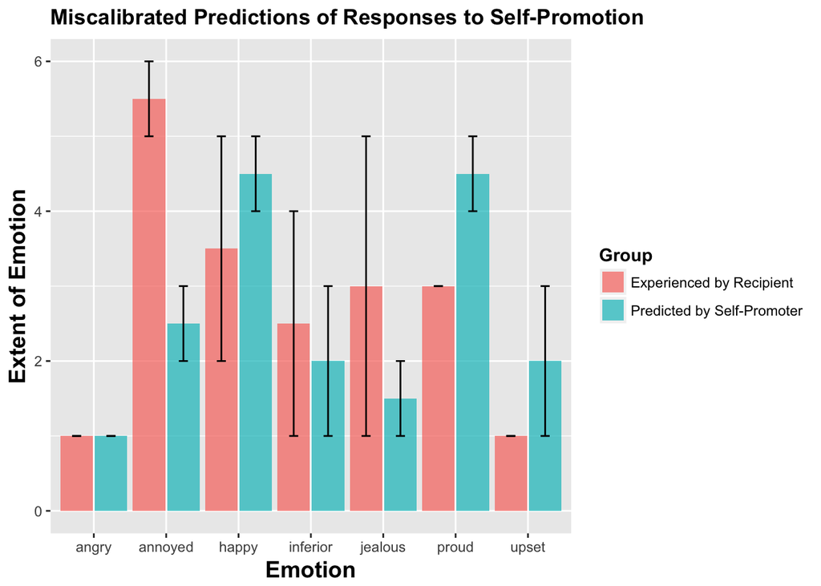

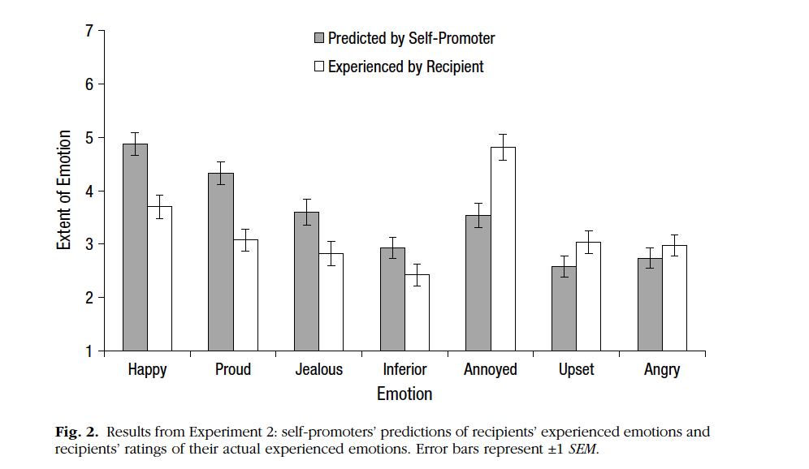

```r
Fig1_plot = ggplot(Fig1, aes(x = factor(Emo), y = mn, fill = factor(Cond)))+geom_bar(width=.9, stat = 'identity', position=position_dodge(.95),size=1.5,alpha = 0.7)+labs(title = "Miscalibrated Predictions of Responses to Self-Promotion", y="Extent of Emotion",x="Emotion")+geom_errorbar(limits,color = 'black',position=position_dodge(.95),width=0.25) + labs(color = "Group") + theme(axis.title=element_text(face="bold",size="14", color="black")) + theme(title = element_text(face = "bold")) +  scale_fill_discrete("Group", labels = c("Experienced by Recipient", "Predicted by Self-Promoter"))
print(Fig1_plot)
```

This replication graph and the screenshot of the original graph (Fig. 2) shows self-Promoters’ predictions of recipients’ experienced emotions and recipients’ ratings of their actual experienced emotions. I do re-create this graph as well from the authors’ data below when I check my statistical tests on their data to ensure it looks the same as what is reported. Error bars represent +/-1 SEM. For the replication graph, some of the error bars are huge due to the low N of this pilot. Overall, however, the replicated visualization is difficult to interpret given the non-significant interaction of emotion and condition and the low N of this pilot.

#### Testing my ANOVA models and Graphing the interaction from Original Data

##### Data Preparation

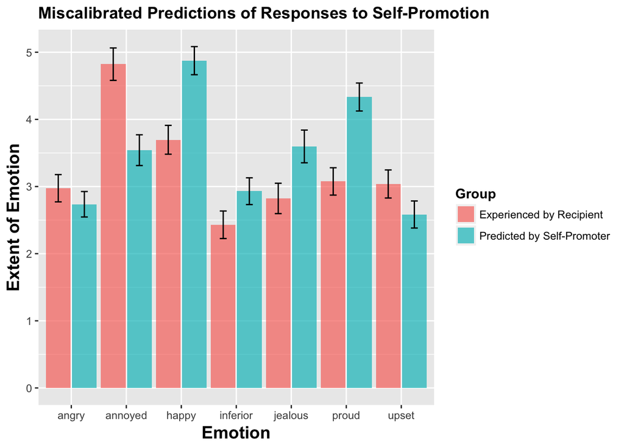

```r
Fig1_Original_plot = ggplot(Fig1_Orignal, aes(x = factor(Emotion), y = mn, fill = factor(reporter)))+geom_bar(width=.9, stat = 'identity', position=position_dodge(.95),size=1.5,alpha = 0.7)+labs(title = "Miscalibrated Predictions of Responses to Self-Promotion", y="Extent of Emotion",x="Emotion")+geom_errorbar(limits,color = 'black',position=position_dodge(.95),width=0.25) + labs(color = "Group") + theme(axis.title=element_text(face="bold",size="14", color="black")) + theme(title = element_text(face = "bold")) +  scale_fill_discrete("Group", labels = c("Experienced by Recipient", "Predicted by Self-Promoter"))
print(Fig1_Original_plot)
```

The graph recreated from the authors’ data does seem to replicate.

##### Confirmatory Analysis

```r
# With Covariates (Between-subjects factor estimated with inclusion of the topic covariates)
Study2Cond_aov <- aov(Rating ~ (reporter) + ach_dummy + ind_skill_d + poss_money_status_power_dummy + fam_rel_dummy + luck_dummy + Error(subj/(Emotion)), data = study2_long) # 0 = RSP, 1 = SP
Study2Cond_aov_sum <- summary(Study2Cond_aov)
print(Study2Cond_aov_sum)
```

```
##
## Error: subj
##                                Df Sum Sq Mean Sq F value Pr(>F)
## reporter                        1   16.2  16.226   2.845 0.0938 .
## ach_dummy                       1    2.6   2.622   0.460 0.4988
## ind_skill_d                     1    5.2   5.232   0.917 0.3398
## poss_money_status_power_dummy   1    4.2   4.193   0.735 0.3927
## fam_rel_dummy                   1    6.8   6.788   1.190 0.2772
## luck_dummy                      1    5.3   5.314   0.932 0.3361
## Residuals                     144  821.4   5.704
## ---
## Signif. codes:  0 '***' 0.001 '**' 0.01 '*' 0.05 '.' 0.1 ' ' 1
##
## Error: subj:Emotion
##            Df Sum Sq Mean Sq F value Pr(>F)
## Residuals 906   3366   3.716
```

```r
# Without Covariates (Within-subjects factor estimated without inclusion of the topic covariates)
Emo_aov_noCov <- aov(Rating ~ (Emotion) + Error(subj/(Emotion)), data = study2_long)
Emo_aov_noCov_sum <- summary(Emo_aov_noCov)
print(Emo_aov_noCov_sum)
```

```
##
## Error: subj
##            Df Sum Sq Mean Sq F value Pr(>F)
## Residuals 150  861.8   5.745
##
## Error: subj:Emotion
##            Df Sum Sq Mean Sq F value Pr(>F)
## Emotion     6  403.7   67.28   20.44 <2e-16 ***
## Residuals 900 2962.6    3.29
## ---
## Signif. codes:  0 '***' 0.001 '**' 0.01 '*' 0.05 '.' 0.1 ' ' 1
```

```r
# With Covariates (The interaction was estimated with topic covariates)
Study2mainInt_aov <- aov(Rating ~ (reporter*Emotion) + ach_dummy + ind_skill_d + poss_money_status_power_dummy + fam_rel_dummy + luck_dummy + Error(subj/(Emotion)), data = study2_long)
Study2mainInt_aov_sum <- summary(Study2mainInt_aov)
knitr::kable(broom::tidy(Study2mainInt_aov))
```

| term | df | sumsq | meansq | statistic | p.value | stratum |
| --- | --- | --- | --- | --- | --- | --- |
| ach_dummy | 1 | 2.622466 | 2.622466 | 0.4597503 | 0.4988288 | subj |
| ind_skill_d | 1 | 5.232269 | 5.232269 | 0.9172806 | 0.3397952 | subj |
| poss_money_status_power_dummy | 1 | 4.193007 | 4.193007 | 0.7350852 | 0.3926645 | subj |
| fam_rel_dummy | 1 | 6.787522 | 6.787522 | 1.1899354 | 0.2771645 | subj |
| luck_dummy | 1 | 5.313981 | 5.313981 | 0.9316056 | 0.3360642 | subj |
| Residuals | 144 | 821.391868 | 5.704110 | NA | NA | subj |
| reporter:Emotion | 6 | 199.442705 | 33.240451 | 10.7546988 | 0.0000000 | subj:Emotion |
| Residuals | 894 | 2763.160890 | 3.090784 | NA | NA | subj:Emotion |

##### If gathering the covariates into long format, which I commented out

The degrees of freedom are very off when gathering the topics into long format, whereas when I leave the covariates in wide format the degrees of freedom are only slightly off. Therefore, I think I will continue the analysis with the topic covariates in wide-format and my other variables in long-format.

### Exploratory analyses

If the interaction after actual data collection is significant, here is the code I would use to conduct post-hoc F tests. I am using this code on the authors’ data to see if I get the same results.

```r
# 0 = RSP, 1 = SP
SPcond <- study2[which(study2$reporter == '1'),]
RSPcond <- study2[which(study2$reporter == '0'),]
happy <- study2_long[which(study2_long$Emotion == 'happy'),]
proud <- study2_long[which(study2_long$Emotion == 'proud'),]
annoyed <- study2_long[which(study2_long$Emotion == 'annoyed'),]
jealous <- study2_long[which(study2_long$Emotion == 'jealous'),]
upset <- study2_long[which(study2_long$Emotion == 'upset'),]
angry <- study2_long[which(study2_long$Emotion == 'angry'),]
inferior <- study2_long[which(study2_long$Emotion == 'inferior'),]

# happy
mean(SPcond$happy) # 4.875
```

```
## [1] 4.875
```

```r
sd(SPcond$happy) # 1.775716
```

```
## [1] 1.775716
```

```r
mean(RSPcond$happy) # 3.696203
```

```
## [1] 3.696203
```

```r
sd(RSPcond$happy) # 1.910527
```

```
## [1] 1.910527
```

```r
summary(aov(Rating ~ reporter + ach_dummy + ind_skill_d + poss_money_status_power_dummy + fam_rel_dummy + luck_dummy, data = happy)) # F=15.878, p<.001
```

```
##                                Df Sum Sq Mean Sq F value   Pr(>F)
## reporter                        1   52.3   52.34  15.878 0.000107 ***
## ach_dummy                       1   21.9   21.88   6.636 0.011000 *
## ind_skill_d                     1    6.4    6.39   1.938 0.166084
## poss_money_status_power_dummy   1    2.8    2.82   0.854 0.356922
## fam_rel_dummy                   1    0.0    0.02   0.006 0.938016
## luck_dummy                      1    2.8    2.77   0.840 0.360809
## Residuals                     144  474.7    3.30
## ---
## Signif. codes:  0 '***' 0.001 '**' 0.01 '*' 0.05 '.' 0.1 ' ' 1
```

```r
# proud
mean(SPcond$proud) # 4.333333
```

```
## [1] 4.333333
```

```r
sd(SPcond$proud) # 1.768265
```

```
## [1] 1.768265
```

```r
mean(RSPcond$proud) # 3.075949
```

```
## [1] 3.075949
```

```r
sd(RSPcond$proud) # 1.81003
```

```
## [1] 1.81003
```

```r
summary(aov(Rating ~ reporter + ach_dummy + ind_skill_d + poss_money_status_power_dummy + fam_rel_dummy + luck_dummy, data = proud)) #F=19.406, p<.001
```

```
##                                Df Sum Sq Mean Sq F value   Pr(>F)
## reporter                        1   59.6   59.56  19.406 2.05e-05 ***
## ach_dummy                       1   31.8   31.76  10.349   0.0016 **
## ind_skill_d                     1    0.1    0.11   0.036   0.8498
## poss_money_status_power_dummy   1    1.8    1.76   0.572   0.4507
## fam_rel_dummy                   1    0.8    0.76   0.247   0.6200
## luck_dummy                      1    1.2    1.23   0.401   0.5275
## Residuals                     144  441.9    3.07
## ---
## Signif. codes:  0 '***' 0.001 '**' 0.01 '*' 0.05 '.' 0.1 ' ' 1
```

```r
# annoyed
mean(SPcond$annoyed) # 3.541667
```

```
## [1] 3.541667
```

```r
sd(SPcond$annoyed) # 1.942392
```

```
## [1] 1.942392
```

```r
mean(RSPcond$annoyed) # 4.822785
```

```
## [1] 4.822785
```

```r
sd(RSPcond$annoyed) # 2.146909
```

```
## [1] 2.146909
```

```r
summary(aov(Rating ~ reporter + ach_dummy + ind_skill_d + poss_money_status_power_dummy + fam_rel_dummy + luck_dummy, data = annoyed)) # F=14.544, p<.001
```

```
##                                Df Sum Sq Mean Sq F value   Pr(>F)
## reporter                        1   61.8   61.82  14.544 0.000202 ***
## ach_dummy                       1    6.1    6.13   1.441 0.231941
## ind_skill_d                     1    0.3    0.31   0.073 0.787911
## poss_money_status_power_dummy   1    3.5    3.46   0.814 0.368301
## fam_rel_dummy                   1    0.0    0.00   0.000 0.985715
## luck_dummy                      1    5.4    5.38   1.265 0.262566
## Residuals                     144  612.1    4.25
## ---
## Signif. codes:  0 '***' 0.001 '**' 0.01 '*' 0.05 '.' 0.1 ' ' 1
```

```r
# jealous
mean(SPcond$jealous) # 3.597222
```

```
## [1] 3.597222
```

```r
sd(SPcond$jealous) # 2.066907
```

```
## [1] 2.066907
```

```r
mean(RSPcond$jealous) # 2.822785
```

```
## [1] 2.822785
```

```r
sd(RSPcond$jealous) # 2.011247
```

```
## [1] 2.011247
```

```r
summary(aov(Rating ~ reporter + ach_dummy + ind_skill_d + poss_money_status_power_dummy + fam_rel_dummy + luck_dummy, data = jealous)) # F=5.526, p=0.020
```

```
##                                Df Sum Sq Mean Sq F value Pr(>F)
## reporter                        1   22.6  22.592   5.526 0.0201 *
## ach_dummy                       1    5.0   5.040   1.233 0.2687
## ind_skill_d                     1    0.4   0.401   0.098 0.7545
## poss_money_status_power_dummy   1    8.7   8.729   2.135 0.1461
## fam_rel_dummy                   1   12.6  12.561   3.072 0.0818 .
## luck_dummy                      1    3.4   3.383   0.827 0.3645
## Residuals                     144  588.7   4.088
## ---
## Signif. codes:  0 '***' 0.001 '**' 0.01 '*' 0.05 '.' 0.1 ' ' 1
```

```r
# upset
mean(SPcond$upset) # 2.583333
```

```
## [1] 2.583333
```

```r
sd(SPcond$upset) # 1.709542
```

```
## [1] 1.709542
```

```r
mean(RSPcond$upset) # 3.037975
```

```
## [1] 3.037975
```

```r
sd(RSPcond$upset) # 1.856679
```

```
## [1] 1.856679
```

```r
summary(aov(Rating ~ reporter + ach_dummy + ind_skill_d + poss_money_status_power_dummy + fam_rel_dummy + luck_dummy, data = upset)) # F=2.429, p=0.121
```

```
##                                Df Sum Sq Mean Sq F value Pr(>F)
## reporter                        1    7.8   7.786   2.429 0.1213
## ach_dummy                       1    9.0   9.029   2.817 0.0954 .
## ind_skill_d                     1    0.2   0.250   0.078 0.7806
## poss_money_status_power_dummy   1    3.8   3.771   1.176 0.2799
## fam_rel_dummy                   1    0.1   0.099   0.031 0.8608
## luck_dummy                      1    1.7   1.684   0.525 0.4697
## Residuals                     144  461.6   3.205
## ---
## Signif. codes:  0 '***' 0.001 '**' 0.01 '*' 0.05 '.' 0.1 ' ' 1
```

```r
# angry
mean(SPcond$angry) # 2.736111
```

```
## [1] 2.736111
```

```r
sd(SPcond$angry) # 1.609768
```

```
## [1] 1.609768
```

```r
mean(RSPcond$angry) # 2.974684
```

```
## [1] 2.974684
```

```r
sd(RSPcond$angry) # 1.804373
```

```
## [1] 1.804373
```

```r
summary(aov(Rating ~ reporter + ach_dummy + ind_skill_d + poss_money_status_power_dummy + fam_rel_dummy + luck_dummy, data = angry)) # F=0.743, p=0.390
```

```
##                                Df Sum Sq Mean Sq F value Pr(>F)
## reporter                        1    2.1   2.144   0.743 0.3902
## ach_dummy                       1    5.0   4.952   1.716 0.1923
## ind_skill_d                     1   10.9  10.856   3.761 0.0544 .
## poss_money_status_power_dummy   1    2.9   2.877   0.997 0.3198
## fam_rel_dummy                   1    1.3   1.282   0.444 0.5061
## luck_dummy                      1    2.3   2.344   0.812 0.3690
## Residuals                     144  415.6   2.886
## ---
## Signif. codes:  0 '***' 0.001 '**' 0.01 '*' 0.05 '.' 0.1 ' ' 1
```

```r
# inferior
mean(SPcond$inferior) # 2.930556
```

```
## [1] 2.930556
```

```r
sd(SPcond$inferior) # 1.689457
```

```
## [1] 1.689457
```

```r
mean(RSPcond$inferior) # 2.43038
```

```
## [1] 2.43038
```

```r
sd(RSPcond$inferior) # 1.823518
```

```
## [1] 1.823518
```

```r
summary(aov(Rating ~ reporter + ach_dummy + ind_skill_d + poss_money_status_power_dummy + fam_rel_dummy + luck_dummy, data = inferior)) # F=2.985, p=0.0862
```

```
##                                Df Sum Sq Mean Sq F value Pr(>F)
## reporter                        1    9.4   9.424   2.985 0.0862 .
## ach_dummy                       1    0.3   0.323   0.102 0.7496
## ind_skill_d                     1    0.5   0.462   0.146 0.7025
## poss_money_status_power_dummy   1    0.0   0.001   0.000 0.9855
## fam_rel_dummy                   1    3.1   3.114   0.987 0.3222
## luck_dummy                      1    3.6   3.557   1.127 0.2902
## Residuals                     144  454.6   3.157
## ---
## Signif. codes:  0 '***' 0.001 '**' 0.01 '*' 0.05 '.' 0.1 ' ' 1
```

The code above to replicate the means and standard deviations of the original data matches what was reported, except there are a few minor errors, which may have been typos in the paper. Only the standard deviations within *proud*, *jealous*, and *inferior* are switched between the two conditions in the paper compared to what has been yielded from the code above. For the simple effects F tests, I tested multiple models on the original data. Every function (anova on lmer, aov, ezANOVA) yields the same F statistics and p values, but the degrees of freedom differ amongst each function. When matching these statistics to those reported in the paper, the F statistics are off by a few numbers, but it doesn’t change the conclusion drawn from simple effects in the paper. The aov function seems to be the closest to the degrees of freedom reported in the paper when testing this code on the authors’ data, so I may continue to use that function for the main effects, interaction effect, and simple effects for the actual replication.

## Discussion

### Summary of Replication Attempt

The pilot data fails to replicate the main interaction of *Condition* and *Emotion*, which is likely due to the low N of this pilot. However, I did replicate the significant main effect of *Emotion* and non-significant main effect of *Condition*. I would consider this a partial replication for this pilot data. Given the several different ways to conduct F tests (which is the test done in the paper), this pilot helped in deciding how to code the statistical tests for actual data collection.

### Commentary

1. The results with pilot data are difficult to interpret given this pilot data consists of 4 participants and was only intended to test the viability and the code that I will eventually use for actual data collection. Therefore, I used the authors’ data to test the exploratory code I would use to conduct post-hoc tests if the interaction ends up being significant.
2. Although this replication partially failed, the F statistic is in the right direction and with more people, might attain significance.
3. One thing to note is that I coded the topics of bragging myself instead of having 2 RAs code these topics since this is the pilot. I will be having another student help me code these topics for actual data collection. I plan to use aov instead of ezANOVA because of the warning that ezANOVA “is experimental and not yet fully validated.” The aov function seems to be working well with how I formatted the data, so I may keep it that way moving forward with the replication, but any feedback on this is appreciated!